# 20180632_mariaangelicafernandez_sesion2

## Empezar por guardar el documento y abrir la base de datos

```r
setwd("~/Desktop/Estadistica2/ClasesR")
library(rio)
library(car)
library(carData)
library(nortest)
data=import("idh_elec.csv")
names(data)
```

```
##  [1] "ubiReg"         "ubiProv"        "ubiDis"         "depa"
##  [5] "prov"           "dist"           "pobla"          "idh"
##  [9] "esperanza"      "secundaria"     "tiempoedu"      "percapitaf"
## [13] "votos_PPK"      "votos_FP"       "porcentaje_PPK" "porcentaje_FP"
```

## Regresion Lineal Multiple

```r
modelo1=lm(votos_PPK ~ esperanza + secundaria + tiempoedu + percapitaf,data=data)
summary(modelo1)
```

```
##
## Call:
## lm(formula = votos_PPK ~ esperanza + secundaria + tiempoedu +
##     percapitaf, data = data)
##
## Residuals:
##    Min     1Q Median     3Q    Max
## -32901  -4531   -735   2662 243816
##
## Coefficients:
##               Estimate Std. Error t value Pr(>|t|)
## (Intercept) -17776.398   4673.303  -3.804 0.000147 ***
## esperanza       90.945     64.967   1.400 0.161723
## secundaria      -9.571     22.118  -0.433 0.665264
## tiempoedu     1259.284    337.408   3.732 0.000196 ***
## percapitaf      19.299      2.138   9.027  < 2e-16 ***
## ---
## Signif. codes:  0 '***' 0.001 '**' 0.01 '*' 0.05 '.' 0.1 ' ' 1
##
## Residual standard error: 13960 on 1829 degrees of freedom
## Multiple R-squared:  0.2168, Adjusted R-squared:  0.2151
## F-statistic: 126.6 on 4 and 1829 DF,  p-value: < 2.2e-16
```

Crear otro modelo agregando variable "numero de habitantes: modelo2=lm(votos_PPK ~ esperanza + secundaria + tiempoedu + percapitaf + pobla,data=data) summary(modelo2)

-> Seguimos nuestro flujograma para evaluar el modelo: 1. Nos preguntamos si el modelo es válido 2. Qué tanto explica el modelo 3. Si las variables independientes aportan al modelo 4. Identificamos los coeficientes

```r
coefficients(modelo1)
```

```
##   (Intercept)     esperanza    secundaria     tiempoedu    percapitaf
## -17776.397739     90.944994     -9.570903   1259.284400     19.299037
```

### 1- Linealidad

**Descripcion** La linealidad indica que el valor esperado de la variable dependiente es una función lineal de cada variable independiente, manteniendo las demás fijas. La pendiente de esa línea no depende de los valores de las otras variables. Los efectos de diferentes variables independientes sobre el valor esperado de la variable dependiente son aditivos.

**Como detectarlo** Exploración gráfica: Plot de valores residuales frente a valores predichos.

**Código e interpretación**

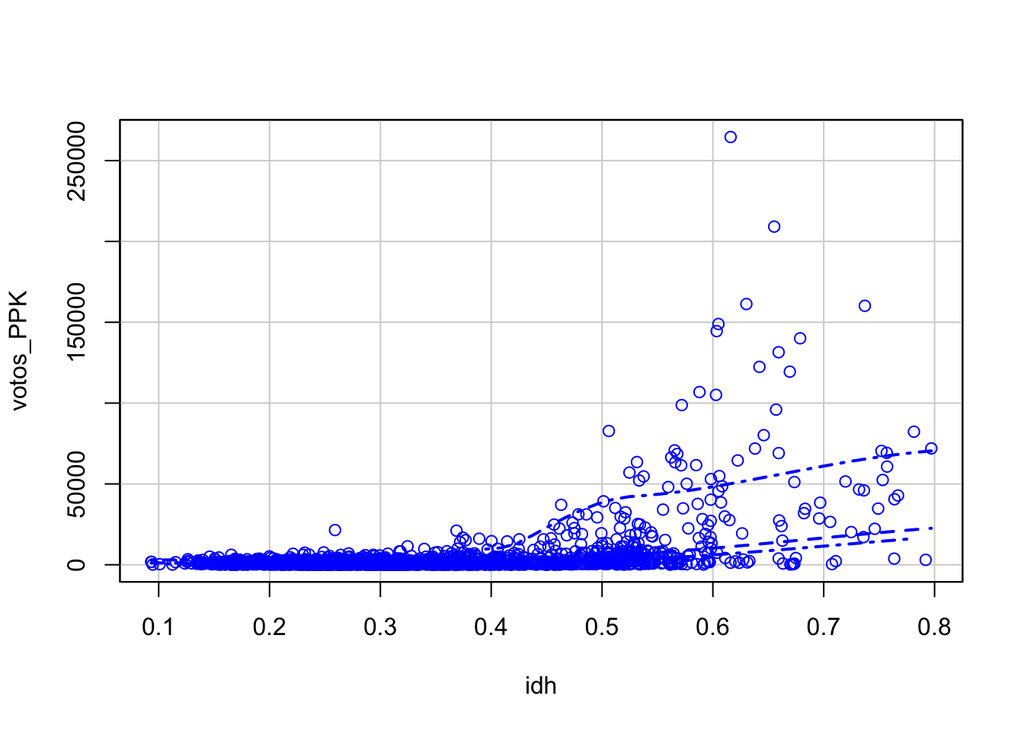

```r
library(car)
scatterplot(votos_PPK~idh, regLine=FALSE, smooth=TRUE, boxplots=FALSE, data=data)
```

### 2- Normalidad de Residuos

**Descripcion** Identificar si los errores siguen una distribución normal.

**Como detectarlo** Exploración gráfica: QQ plot de residuos Pruebas de normalidad a los residuos. Normalmente bastaría con la prueba de Shapiro Wilk, pero también se pueden probar otros como Lillieford, Kolmogorov (no es muy exigente), entre otros.

**Código e interpretación**

```r
library(nortest)
residuos=modelo1$residuals
lillie.test(residuos)
```

```
##
##  Lilliefors (Kolmogorov-Smirnov) normality test
##
## data:  residuos
## D = 0.25276, p-value < 2.2e-16
```

H0: Es normal | Ha: No es normal Si el pvalor es menor a 0.05 entonces no existe normalidad de residuos (problema!). Aqui sale que es 2.2e-16 no existe una normalidad de residuos lo que puede afectar a mi regresión.

### 3- Homocedasticidad

**Descripcion** La homocedasticidad indica que las variancias de los errores son constantes. Cuando no se cumple (si el error no es constante) es un problema porque los estimadores no son consistentes ni eficientes.

**Como detectarlo** OPCIÓN 1: Exploración gráfica: diagrama de residuos standarizados y valores predichos. OPCIÓN 2: Con el Score Test for Non-Constant Error Variance, también llamado Test Breusch Pagan. Evalúa si la varianza del error cambia con el nivel de la variable respuesta (valores ajustados) o con una combinación lineal de predictores.

**Código e interpretación**

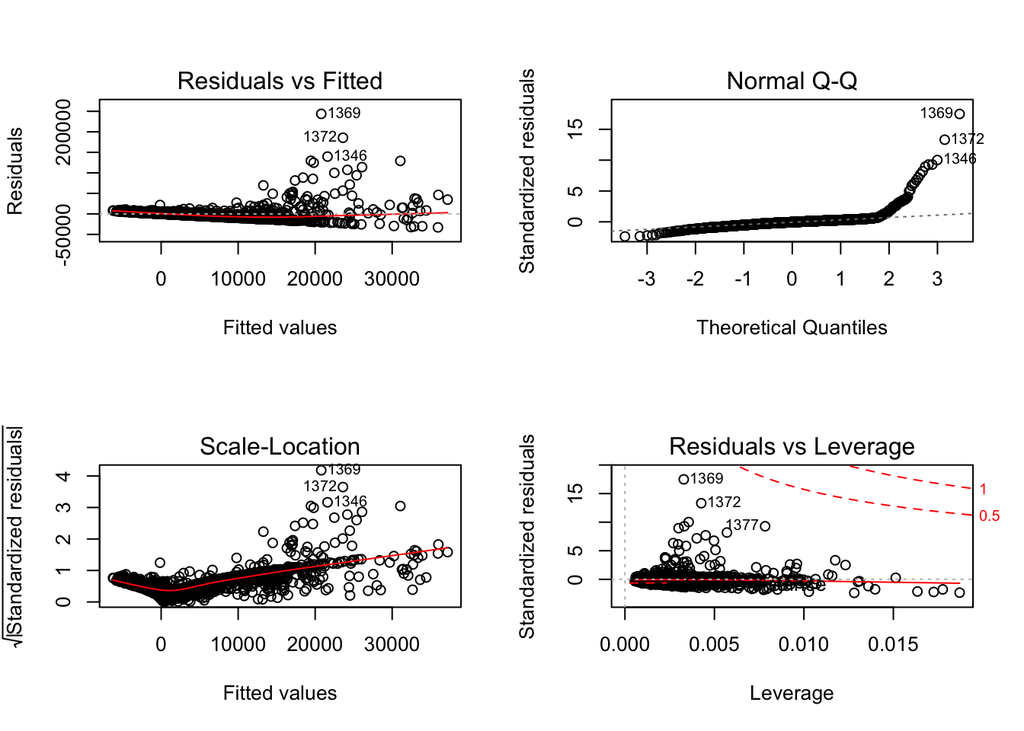

```r
par(mfrow = c(2,2))
plot(modelo1)
library(lmtest)
```

```r
library(zoo)
```

### 4- No Multicolinealidad

**Descripcion** Se aplica en la regresión lineal MÚLTIPLE. Significa que las variables explicativas están relacionadas lin- ealmente entre sí. La multicolinealidad hace que los coeficientes del modelo se vuelvan inestables, es decir, oscilarán violentamente ante cambios mínimos en las variables de insumo.

**Como detectarlo** Con el Factor de inflación de varianza (VIF)

**Codigo e interpretacion**

```r
library(DescTools)
VIF(modelo1)
```

```
##  esperanza secundaria  tiempoedu percapitaf
##   1.111531   2.346505   4.637456   2.927932
```

### 5- Independencia de residuos / No autocorrrelación

**Descripcion** Si los errores residuales no son independientes, es probable que demuestren algún tipo de patrón (que no siempre es obvio a simple vista).

**Como detectarlo** OPCIÓN1: Se puede hacer una exploración gráfica: diagrama de dispersión de los valores pronosticados vs los residuos. OPCIÓN2: También se puede realizar el Test de Durbin Watson (que mide el grado de correlación de cada error residual con el error residual “anterior”)

**Codigo e interpretacion**

```r
library(lmtest)
dwtest(votos_PPK ~ esperanza + secundaria + tiempoedu + percapitaf,alternative="greater", data=data)
```

```
##
##  Durbin-Watson test
##
## data:  votos_PPK ~ esperanza + secundaria + tiempoedu + percapitaf
## DW = 1.5154, p-value < 2.2e-16
## alternative hypothesis: true autocorrelation is greater than 0
```

Hnula: no hay correlacion de residuos. Como el DW esta entre el 1.5 y el 2.5, si cumple. Pero, es un caso problemático.

### 6 PRESENTACIÓN DEL MODELO LINEAL DE REGRESION

```r
library(stargazer)
stargazer(modelo1, title = "modelo estimado", type = "text")
```

```
##
## modelo estimado
## ===============================================
##                         Dependent variable:
##                     ---------------------------
##                              votos_PPK
## -----------------------------------------------
## esperanza                     90.945
##                              (64.967)
##
## secundaria                    -9.571
##                              (22.118)
##
## tiempoedu                  1,259.284***
##                              (337.408)
##
## percapitaf                   19.299***
##                               (2.138)
##
## Constant                  -17,776.400***
##                             (4,673.303)
##
## -----------------------------------------------
## Observations                   1,834
## R2                             0.217
## Adjusted R2                    0.215
## Residual Std. Error   13,963.640 (df = 1829)
## F Statistic          126.604*** (df = 4; 1829)
## ===============================================
## Note:               *p<0.1; **p<0.05; ***p<0.01
```